# PSCI 2075 Exam I Practice Quiz

Alex Newhouse

2025-09-30

# Instructions

This practice quiz covers all topics from the Exam I Study Guide. Work through each section, write your answers in the code chunks provided, and check your work using the solutions at the bottom of each section.

**Tips:** - Actually write out the code and run it! - Try to answer without looking at solutions first - If you get stuck, review your notes before checking the solution

## Setup: Load Your Data

```r
# Load necessary packages
library(tidyverse)  # Remember, tidyverse is a collection of packages. If you want to load individually: library(ggplot2), library(dplyr)

# If you don't have tidyverse installed, uncomment and run:
# install.packages("tidyverse")
```

```r
# Load the data after setting your working directory to your course folder
load("PSCI_2075_v2.1.RData")
```

# Section 1: Variable Types

## Question 1.1: Identify Variable Types

For each variable below, identify if it is **continuous/numeric** or **categorical**:

```r
# a) states$murderrate
# Your answer:

# b) states$region
# Your answer:

# c) world$regime
# Your answer:

# d) nes$gender
# Your answer:

# e) nes$ftobama (feeling thermometer 0-100)
# Your answer:
```

**Click to see Solution 1.1**

```r
# Check variable types
class(states$murderrate)  # numeric - continuous
```

```
## [1] "numeric"
```

```r
class(states$region)       # character - categorical
```

```
## [1] "factor"
```

```r
class(world$regime)        # character - categorical
```

```
## [1] "factor"
```

```r
class(nes$gender)          # character - categorical
```

```
## [1] "factor"
```

```r
class(nes$ftobama)         # integer/numeric
```

```
## [1] "integer"
```

```r
# Better way to check multiple at once:
str(states[, c("murderrate", "region")])
```

```
## 'data.frame':    50 obs. of  2 variables:
##  $ murderrate: num  6.9 3.1 5.4 6.2 5.3 3.5 3 4.6 5.5 5.8 ...
##  $ region    : Factor w/ 4 levels "South","West",..: 1 2 2 1 2 2 4 1 1 1 ...
```

**Answers:** - a) Continuous/numeric - b) Categorical - c) Categorical - d) Categorical - e) Continuous/numeric

## Question 1.2: Why Does Variable Type Matter?

In your own words: Why do we care about whether a variable is continuous or categorical?

**Your answer here:**

**Click to see Solution 1.2**

**Sample answer:** Variable type determines: 1. Which summary statistics we can use (mean for continuous, mode/frequency for categorical) 2. Which visualizations are appropriate (histogram for continuous, bar chart for categorical) 3. Which statistical tests we can apply 4. How we interpret the data (categories vs. measurements)

# Section 2: Data Import and Exploration

## Question 2.1: Loading Packages

**Fill in the blanks:**

To install a package in R, use: `____________("package_name")`

To load a package in R, use: `____________(package_name)`

**Click to see Solution 2.1**

- Install: `install.packages("package_name")`
- Load: `library(package_name)`

**Note:** You only install once, but load every time you start a new R session!

## Question 2.2: Exploring Data

Use the `world` dataset to answer:

```r
# a) How many rows (observations) are in the world dataset?


# b) How many columns (variables) are in the world dataset?


# c) What are the names of the first 5 variables?


# d) Display the first 6 rows of data
```

**Click to see Solution 2.2**

```r
# a) Number of rows
nrow(world)
```

```
## [1] 182
```

```r
# b) Number of columns
ncol(world)
```

```
## [1] 42
```

```r
# c) First 5 variable names
names(world)[1:5]
```

```
## [1] "iso3c"   "fdi"     "nourish" "aid"     "oil"
```

```r
# or: colnames(world)[1:5]

# d) First 6 rows
head(world)
```

```
##   iso3c        fdi nourish         aid          oil homicide  military infemale
## 1   AFG  0.3400968    24.7 40.45103119  0.002378189      3.5 1.8974728     70.7
## 2   AGO -3.9131508    20.7  0.31614304 38.618626728       NA 4.2448843    100.6
## 3   ALB  9.1340709      NA  3.09176990  1.530367571      4.4 1.5585919     13.2
## 4   ARE  3.0752631     5.0          NA 20.177806945      0.8 6.1194678      6.5
## 5   ARG  2.6751617     5.0  0.03136884  2.129501789       NA 0.8148781     11.6
## 6   ARM  5.7160378     6.5  3.52510840  0.000000000      1.9 4.2656461     14.3
##     inf infmale       co2     trade   health     gdppc womleg gtbeduc
## 1  75.1    79.3 0.5315226  54.96733 9.197723  1629.167   27.7 0.62951
## 2 109.6   117.9 0.3523340 105.33771 3.391146  6360.849   38.6 0.78801
## 3  14.8    16.4 0.3855484  85.46456 5.335035  9646.582   16.4 0.98444
## 4   7.3     8.0 0.5621849 151.00043 3.929452 56245.478   22.5      NA
## 5  13.0    14.4 0.4435952  34.97101 6.550156 18333.995   38.5 1.03598
## 6  16.1    17.9 0.4553910  66.14729 4.562263  6376.268    9.2      NA
##                region              country cid imfcode politycode bankscode
```

[output cut: 27 more lines]

# Section 3: Univariate Summary Statistics

## Question 3.1: Calculate Summary Statistics

Using the `states` dataset, calculate the following for the variable `murderrate`:

```r
# a) Mean


# b) Median


# c) Variance


# d) Standard deviation


# e) 25th percentile (Q1)


# f) 75th percentile (Q3)


# g) All of the above at once using one function
```

**Click to see Solution 3.1**

```r
# a) Mean
mean(states$murderrate)
```

```
## [1] 4.276
```

```r
# b) Median
median(states$murderrate)
```

```
## [1] 4.3
```

```r
# c) Variance
var(states$murderrate)
```

```
## [1] 5.151657
```

```r
# d) Standard deviation
sd(states$murderrate)
```

```
## [1] 2.269726
```

```r
# e) 25th percentile
quantile(states$murderrate, 0.25)
```

```
##   25%
## 2.525
```

```r
# f) 75th percentile
quantile(states$murderrate, 0.75)
```

```
##   75%
## 5.875
```

```r
# g) All at once
summary(states$murderrate)
```

```
##    Min. 1st Qu.  Median    Mean 3rd Qu.    Max.
##   0.800   2.525   4.300   4.276   5.875  11.800
```

**Note:** Always use `na.rm = TRUE` if there are missing values in your column.

## Question 3.2: Skewness Interpretation

Look at this distribution of GDP per capita in the world dataset:

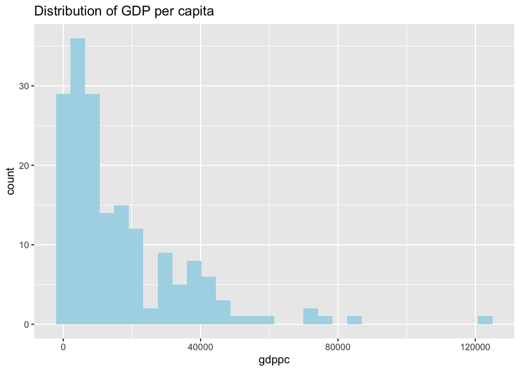

**Questions:**

1. Is this distribution left-skewed or right-skewed?

**Your answer:**

2. In a right-skewed distribution, is the mean greater than or less than the median? Why?

**Your answer:**

**Click to see Solution 3.2**

```r
# Check actual values
mean(world$gdppc, na.rm = TRUE)
```

```
## [1] 16326.78
```

```r
median(world$gdppc, na.rm = TRUE)
```

```
## [1] 9863.205
```

**Answers:**

1. This is **right-skewed** (has a long tail to the right)
2. In a right-skewed distribution, the **mean is greater than the median** because the extreme high values pull the mean upward, but the median is resistant to outliers.

**Mnemonic:** The skew points in the direction of the tail!

## Question 3.3: Mode

What is the **mode** of the following variable, and how would you find it?

```r
# Find the mode (most common value) of states$region
```

**Click to see Solution 3.3**

```r
# R doesn't have a built-in mode function!
# For categorical variables, use table()
table(states$region)
```

```
##
##     South      West   Midwest Northeast
##        16        13        12         9
```

```r
# The mode is the value with the highest frequency
# Or use sort:
sort(table(states$region), decreasing = TRUE)
```

```
##
##     South      West   Midwest Northeast
##        16        13        12         9
```

**Answer:** The mode is “South” (appears most frequently)

**Definition:** The mode is the most frequently occurring value in a dataset. It’s most useful for categorical data.

# Section 4: Data Visualization

## Question 4.1: Match Plot Types to Variables

**Match each plot type with the correct variable combination:**

Plot Types: - A) Histogram - B) Scatterplot  
- C) Boxplot - D) Bar chart - E) Mosaic plot

Variable Combinations: 1. One continuous variable 2. Two continuous variables 3. One continuous, one categorical 4. One categorical variable 5. Two categorical variables

**Your answers:** - A matches with: ____ - B matches with: ____ - C matches with: ____ - D matches with: ____ - E matches with: ____

**Click to see Solution 4.1**

**Answers:** - A (Histogram) matches with: 1 (one continuous) - B (Scatterplot) matches with: 2 (two continuous) - C (Boxplot) matches with: 3 (one continuous, one categorical) - D (Bar chart) matches with: 4 (one categorical) - E (Mosaic plot) matches with: 5 (two categorical)

## Question 4.2: Create Visualizations

Create the following plots using the datasets:

```r
# a) Histogram of world CO2 emissions
```

```r
# b) Scatterplot: states murder rate (x-axis) vs. density (y-axis)
```

```r
# c) Boxplot: compare murder rates across regions in states dataset
```

```r
# d) Bar chart: count of states by region
```

**Click to see Solution 4.2**

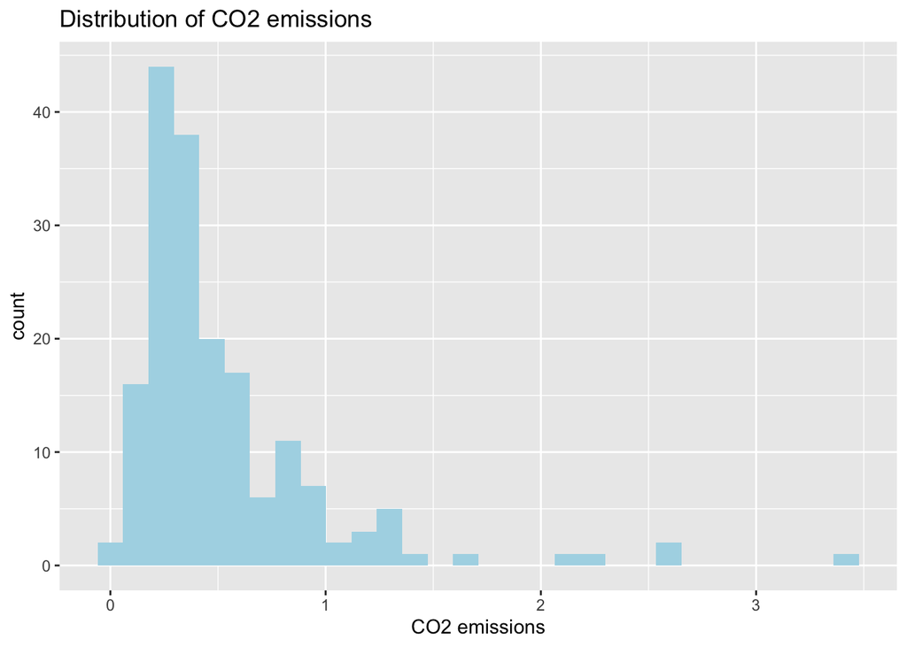

```r
# a) Histogram
# hist(world$lifeexp,
#      main = "Distribution of CO2 emissions",
#      xlab = "CO2 emissions",
#      col = "lightblue")

# Alternative with ggplot2:
ggplot(world, aes(x = co2)) +
  geom_histogram(fill = "lightblue") +
  labs(title = "Distribution of CO2 emissions", x = "CO2 emissions")
```

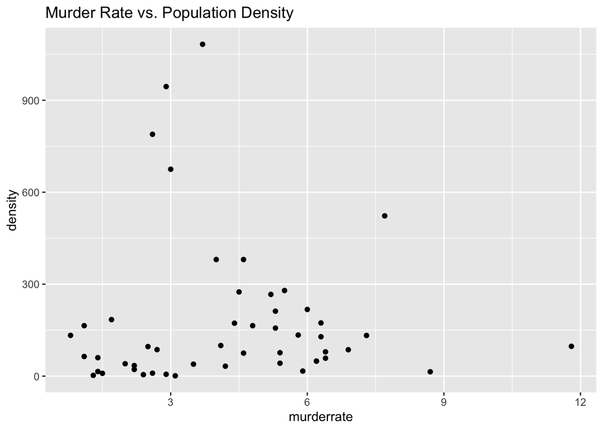

```r
# b) Scatterplot
# plot(states$murderrate, states$density,
#      main = "Murder Rate vs. Population Density",
#      xlab = "Murder Rate",
#      ylab = "Population Density")

# Alternative with ggplot2:
ggplot(states, aes(x = murderrate, y = density)) +
  geom_point() +
  labs(title = "Murder Rate vs. Population Density")
```

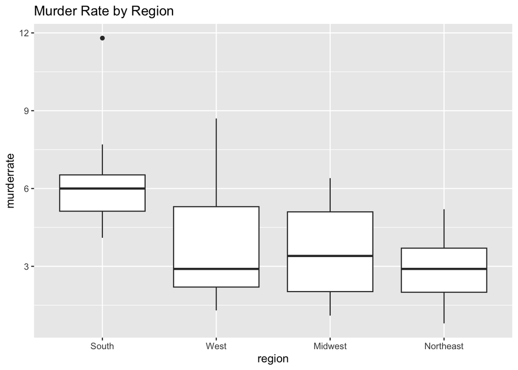

```r
# c) Boxplot
# boxplot(murderrate ~ region, data = states,
#         main = "Murder Rate by Region",
#         xlab = "Region",
#         ylab = "Murder Rate")

# Alternative with ggplot2:
ggplot(states, aes(x = region, y = murderrate)) +
  geom_boxplot() +
  labs(title = "Murder Rate by Region")
```

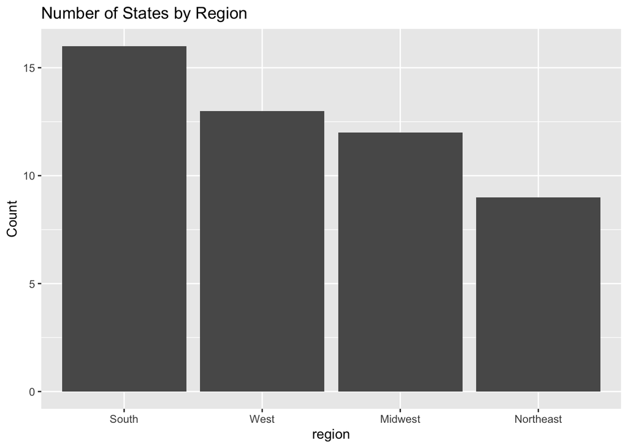

```r
# d) Bar chart
# barplot(table(states$region),
#         main = "Number of States by Region",
#         ylab = "Count",
#         col = "lightgreen")

# Alternative with ggplot2:
ggplot(states, aes(x = region)) +
  geom_bar() +
  labs(title = "Number of States by Region", y = "Count")
```

## Question 4.3: Key Components of a Plot

List and define some of the key components every good plot should have:

**Your answer:**

**Click to see Solution 4.3**

**Key components of a plot:**

1. **Title**: Descriptive title explaining what the plot shows
2. **Axis labels**: Clear labels for x and y axes with units if applicable
3. **Legend** (if needed): Explains colors, shapes, or groups
4. **Appropriate scale**: Axis ranges that show the data clearly
5. **Clear visual encoding**: Appropriate chart type for the data

**Optional but helpful:** - Caption with data source - Gridlines (if they aid interpretation) - Color scheme that’s accessible

# Section 5: Data Manipulation

## Question 5.1: Subsetting Data

```r
# a) Create a subset with only states where trumpwin == 1


# b) Create a subset with states in the "South" region


# c) Create a subset with states where murder rate > 5 AND density > 100


# d) Select only the columns: state, murderrate, and density from states
```

**Click to see Solution 5.1**

```r
# a) States where Trump won
# trump_states <- states[states$trumpwin == 1, ]
# or: subset(states, trumpwin == 1)
trump_states <- states %>%
  filter(trumpwin == 1)

# b) Southern states
# south_states <- states[states$region == "South", ]
# or: subset(states, region == "South")
south_states <- states %>%
  filter(region == "South")

# c) Multiple conditions
# high_murder_dense <- states[states$murderrate > 5 & states$density > 100, ]
# or: subset(states, murderrate > 5 & density > 100)
high_murder_dense <- states %>%
  filter(states$murderrate > 5 & states$density > 100)


# d) Select specific columns
# states_small <- states[, c("state", "murderrate", "density")]
states_small <- states %>%
  select(state, murderrate, density)

# Check your work
head(trump_states)
```

```
##      state st raperate murderrate abort   density     ineq region  gunfree
## 1  Alabama AL     31.9        6.9    16  86.17970 46.01423  South 0.444921
## 2   Alaska AK     73.3        3.1    15   1.08848 34.18490   West 0.932850
## 3  Arizona AZ     32.0        5.4    20  42.12770 49.00724   West 0.969988
## 4 Arkansas AR     47.3        6.2    11  49.10960 46.83973  South 0.520867
## 5  Florida FL     29.7        5.5    32 279.36800 57.52913  South 0.369221
## 6  Georgia GA     23.4        5.8    21 134.10700 47.81453  South 0.590984
##     alcfree    mjfree  marrfree freedom knowgov evangel poptotal stuspend
## 1 -0.024292 -0.054232 -0.009304 21.6063   63.76    42.8  4700000     5273
## 2 -0.003965  0.076145 -0.010426 28.5846   68.44    18.7   686293     8599
## 3  0.016018  0.015321 -0.009304 32.4745   52.10    18.1  6500000     4785
## 4  0.005779 -0.012482 -0.009304 -5.7844   67.08    39.9  2900000     5140
## 5  0.008413 -0.011001 -0.010426 16.9013   70.13    16.9 18000000     5361
## 6 -0.002976 -0.013792 -0.009304 36.6238   64.94    30.3  9700000     6047
##   ptratio hsdiploma democrat       pid house senate   inc minwage year
```

[output cut: 20 more lines]

```r
nrow(south_states)
```

```
## [1] 16
```

## Question 5.2: Variable Recoding

```r
# a) Create a new variable in states called "high_murder" that equals
#    "High" if murderrate > 5 and "Low" otherwise


# b) Create a new variable in world called "gdp_category" with three levels:
#    "Low" if gdppc < 5000
#    "Medium" if gdppc 5000-20000
#    "High" if gdppc > 20000
```

**Click to see Solution 5.2**

```r
# a) Binary recode
states <- states %>%
  mutate(high_murder = case_when(murderrate > 5 ~ "High",
                                 TRUE ~ "Low"))

# Check it worked
table(states$high_murder)
```

```
##
## High  Low
##   20   30
```

```r
# b) Multiple category recode
world <- world %>%
  filter(!is.na(gdppc)) %>%
  mutate(gdp_category = case_when(gdppc < 5000 ~ "Low",
                                  gdppc > 20000 ~ "High",
                                  TRUE ~ "Medium"))

# world$gdp_category <- ifelse(world$gdppc < 5000, "Low",
#                               ifelse(world$gdppc <= 20000, "Medium", "High"))

# or with cut():
world$gdp_category2 <- cut(world$gdppc,
                            breaks = c(-Inf, 5000, 20000, Inf),
                            labels = c("Low", "Medium", "High"))

# Check it worked
table(world$gdp_category, useNA = "always")
```

```
##
##   High    Low Medium   <NA>
##     50     58     68      0
```

## Question 5.3: Variable Transformations

```r
# a) Create a log-transformed version of world$gdppc called gdppc_log


# b) Why might we want to log-transform GDP per capita?
# Your answer:


# c) Create a per-capita version of states$stuspend (student spending)
#    by dividing by poptotal and multiplying by 1000 (per capita in thousands)
```

**Click to see Solution 5.3**

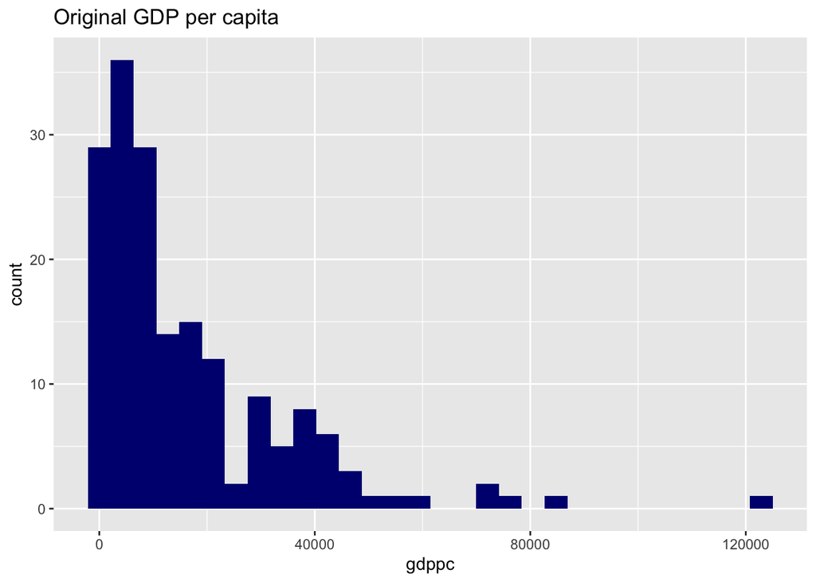

```r
# a) Log transformation
world$gdppc_log <- log(world$gdppc)

# Compare distributions
# par(mfrow = c(1, 2))  # Side by side plots
# hist(world$gdppc, main = "Original GDP per capita")
# hist(world$gdppc_log, main = "Log GDP per capita")

world %>%
  ggplot() +
  geom_histogram(aes(x = gdppc), fill = "navy") +
  labs(
    title = "Original GDP per capita"
  )
```

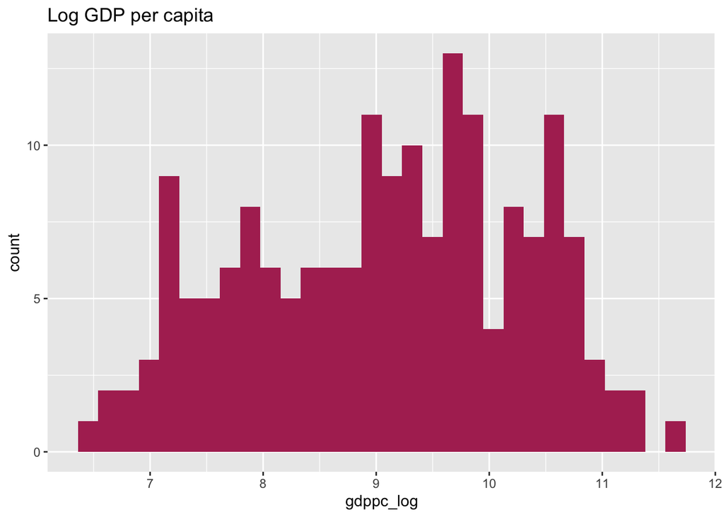

```r
world %>%
  ggplot() +
  geom_histogram(aes(x = gdppc_log), fill = "maroon") +
  labs(
    title = "Log GDP per capita"
  )
```

```r
# b) Why log-transform?
# - GDP is right-skewed; log makes it more normally distributed
# - Makes it easier to see patterns across all values
# - Helps meet assumptions for some statistical tests
# - Proportional changes become linear

# c) Per capita calculation
states$stuspend_pc <- (states$stuspend / states$poptotal) * 1000

# Check it worked
summary(states$stuspend_pc)
```

```
##    Min. 1st Qu.  Median    Mean 3rd Qu.    Max.
##  0.1536  0.8458  1.4278  3.0395  3.4125 16.1489
```

# Section 6: Bivariate Descriptive Statistics

## Question 6.1: Relationship Between Variables

```r
# a) Create a scatterplot with a line of best fit


# b) What does the line of best fit tell us? Interpret it in your own words.
# Your answer:
```

**Click to see Solution 6.1**

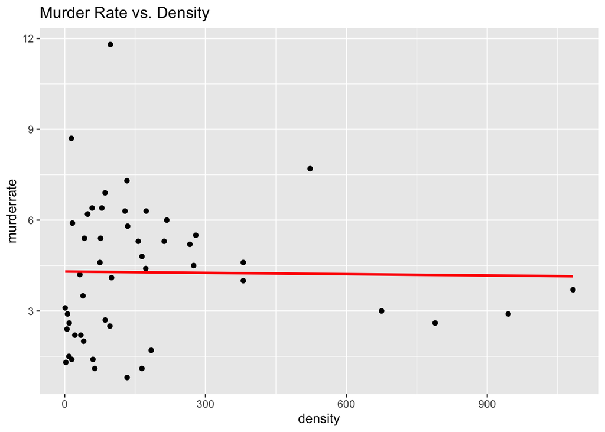

```r
# # a) Scatterplot with line
# plot(states$density, states$murderrate,
#      main = "Murder Rate vs. Density",
#      xlab = "Population Density",
#      ylab = "Murder Rate")
# abline(lm(murderrate ~ density, data = states), col = "red")

# Alternative with ggplot2:
ggplot(states, aes(x = density, y = murderrate)) +
  geom_point() +
  geom_smooth(method = "lm", se = FALSE, color = "red") +
  labs(title = "Murder Rate vs. Density")
```

**Interpretation guide:** - The line of best fit shows any relationship between the x and the y variables - Positive slope = as one increases, other tends to increase - Negative slope = as one increases, other tends to decrease - Closer to 0 = weaker/no relationship

## Question 6.2: Comparing Groups

```r
# Using states data, calculate the mean murder rate for each region
```

**Click to see Solution 6.2**

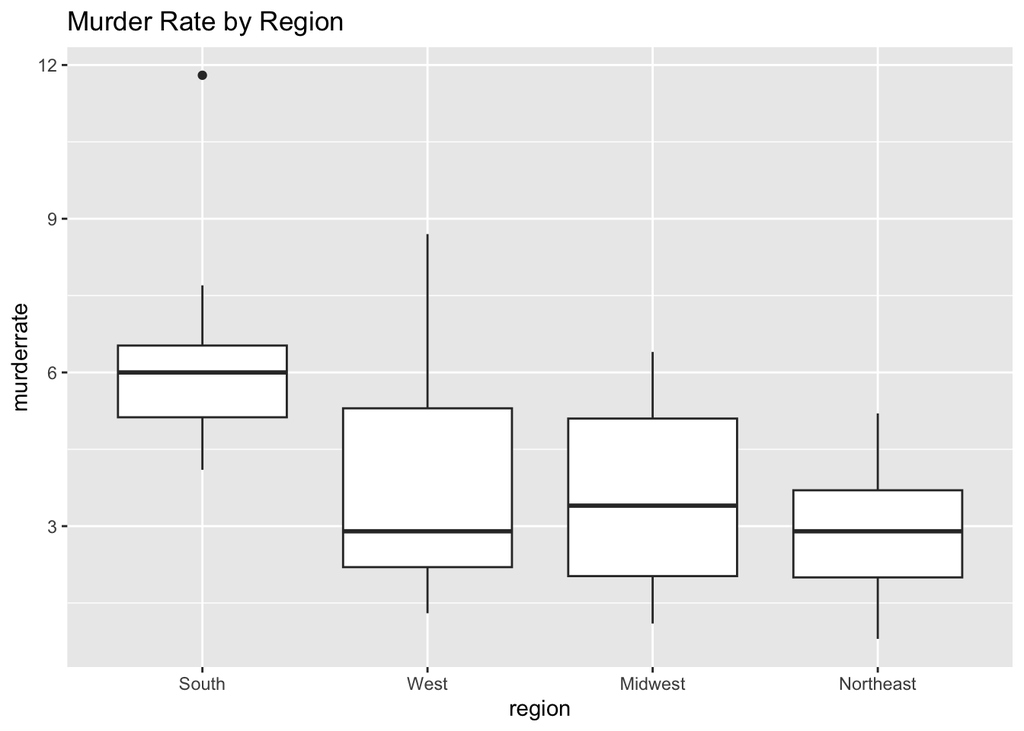

```r
# Base R approach
# tapply(states$murderrate, states$region, mean, na.rm = TRUE)
#
# # Or with aggregate
# aggregate(murderrate ~ region, data = states, FUN = mean)

# Tidyverse approach
library(dplyr)
states_mean <- states %>%
  group_by(region) %>%
  summarize(mean_murder = mean(murderrate, na.rm = TRUE))

# Visualize it
states %>%
  ggplot() +
  geom_boxplot(aes(x = region, y = murderrate)) +
  labs(
    title = "Murder Rate by Region",
    ylab = "Murder Rate"
  )
```

# Section 7: Base R vs. Tidyverse

## Question 7.1: Syntax Comparison

Translate this base R code into tidyverse syntax:

```r
# Base R version:
south <- states[states$region == "South", ]
south_summary <- south[, c("state", "murderrate", "density")]
south_sorted <- south_summary[order(south_summary$murderrate, decreasing = TRUE), ]
```

```r
# Your tidyverse version here:
```

**Click to see Solution 7.1**

```r
# Tidyverse version
library(dplyr)

south_sorted <- states %>%
  filter(region == "South") %>%
  select(state, murderrate, density) %>%
  arrange(desc(murderrate))

# Both produce the same result!
head(south_sorted)
```

```
##            state murderrate  density
## 1      Louisiana       11.8  97.3069
## 2       Maryland        7.7 522.9000
## 3      Tennessee        7.3 132.6950
## 4        Alabama        6.9  86.1797
## 5    Mississippi        6.4  58.5462
## 6 South Carolina        6.3 128.5690
```

**Key tidyverse functions:** - `filter()` = subset rows - `select()` = subset columns - `arrange()` = sort - `mutate()` = create new variables - `summarize()` = aggregate - `group_by()` = group for aggregation - `%>%` = pipe operator (chains operations)

# Section 8: File Types and Workflows

## Question 8.1: R Script vs R Markdown

**Fill in the table:**

| Feature | R Script (.R) | R Markdown (.Rmd) |
| --- | --- | --- |
| File extension |  |  |
| Main purpose |  |  |
| Contains formatted text? |  |  |
| Output format |  |  |
| Best used for… |  |  |

**Click to see Solution 8.1**

| Feature | R Script (.R) | R Markdown (.Rmd) |
| --- | --- | --- |
| File extension | .R | .Rmd |
| Main purpose | Run code | Create reports/documents |
| Contains formatted text? | Only as comments | Yes, markdown formatting |
| Output format | None (just runs code) | HTML, PDF, Word, etc. |
| Best used for… | Data analysis, functions | Reports, homework, presentations |

**R Script:** - Just code and comments - Run line by line or all at once - No formatted output

**R Markdown:** - Combines code, output, and narrative text - Knits to create polished documents - Great for reproducible reports

# Section 9: Practice Problems

## Problem 9.1: Complete Analysis

Using the `world` dataset, do the following:

1. Create a subset with only democracies (polity2 > 5)
2. Calculate mean and median CO2 emissions for democracies
3. Create a histogram of CO2 emissions for democracies
4. Compare to non-democracies using a boxplot

```r
# Your code here:
```

**Click to see Solution 9.1**

```r
# 1. Subset democracies
democracies <- subset(world, polity2 > 5)

# 2. Summary statistics
mean_co2_dem <- mean(democracies$co2, na.rm = TRUE)
median_co2_dem <- median(democracies$co2, na.rm = TRUE)

cat("Mean CO2 emissions in democracies:", round(mean_co2_dem, 1), "\n")
```

```
## Mean CO2 emissions in democracies: 0.5
```

```r
cat("Median CO2 emissions in democracies:", round(median_co2_dem, 1), "\n")
```

```
## Median CO2 emissions in democracies: 0.3
```

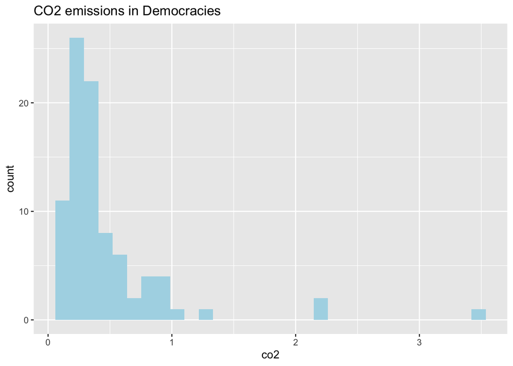

```r
# 3. Histogram
democracies %>%
  ggplot() +
  geom_histogram(aes(x = co2), fill = "lightblue") +
  labs(
    title = "CO2 emissions in Democracies",
    xlab = "CO2 emissions"
  )
```

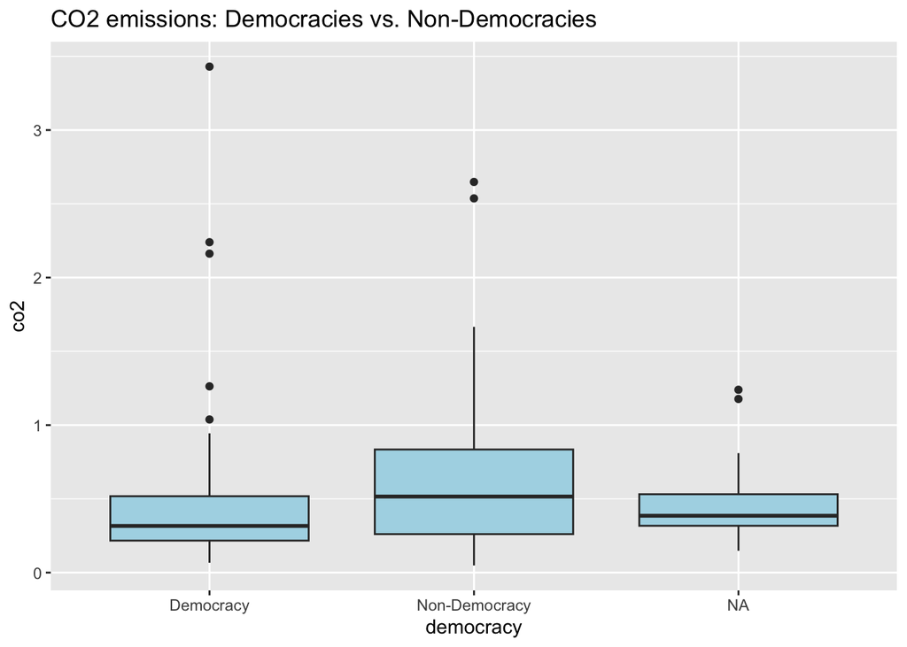

```r
# 4. Comparison boxplot
# First create democracy indicator
world$democracy <- ifelse(world$polity2 > 5, "Democracy", "Non-Democracy")

# boxplot(co2 ~ democracy, data = world,
#         main = "CO2 emissions: Democracies vs. Non-Democracies",
#         ylab = "CO2 emissions",
#         col = c("lightcoral", "lightblue"))

world %>%
  ggplot() +
  geom_boxplot(aes(x = democracy, y = co2), fill = "lightblue") +
  labs(
    title = "CO2 emissions: Democracies vs. Non-Democracies",
    ylab = "CO2 emissions (years)"
  )
```

# Section 9: Conceptual Questions

## Question 9.1: Short Answer

Answer in 2-3 sentences each:

**a) What is data wrangling and why is it important?**

Your answer:

**b) When should you use a log transformation, and what does it do?**

Your answer:

**c) Explain the difference between the mean and median. When might you prefer one over the other?**

Your answer:

**d) Why do we create visualizations instead of just looking at summary statistics?**

Your answer:

**Click to see Sample Answers**

**a) Data wrangling:** The process of cleaning, transforming, and organizing raw data into a format suitable for analysis. It’s important because real-world data is often messy, contains errors, and isn’t structured for the analysis we want to do.

**b) Log transformation:** Use when data is highly right-skewed (like income, GDP). It compresses large values and spreads out small values, making the distribution more symmetric and easier to interpret.

**c) Mean vs. Median:** The mean is the average (sum/count); the median is the middle value. The median is better when you have outliers or skewed data because it’s not affected by extreme values. The mean is better for symmetric distributions and uses all the data.

**d) Visualizations:** They help us see patterns, outliers, and relationships that summary statistics might miss. A famous example is Anscombe’s Quartet—four datasets with identical means, medians, and correlations but completely different patterns visible only in plots.